# Examen

Felipe Clement Santacruz

2019-04-26

# 1 Datos

```r
data <- read.csv("data.csv", sep = ";")
str(data)
```

```
## 'data.frame':    53041 obs. of  105 variables:
##  $ ESTU_TIPODOCUMENTO           : Factor w/ 6 levels "CC","CE","CR",..: 1 1 1 1 1 1 1 1 1 1 ...
##  $ ESTU_NACIONALIDAD            : Factor w/ 21 levels "1 COLOMBIA","112 JAP\xd3N",..: 1 1 1 1 1 1 1 1 1 1 ...
##  $ ESTU_GENERO                  : Factor w/ 3 levels "","F","M": 2 3 3 2 2 3 3 2 3 3 ...
##  $ ESTU_FECHANACIMIENTO         : Factor w/ 10105 levels "","1/01/1956",..: 1 2214 6231 6910 5551 8957 8091 3438 113 4350 ...
##  $ ESTU_EXTERIOR                : Factor w/ 2 levels "NO","SI": 2 1 1 1 1 1 1 1 1 1 ...
##  $ PERIODO                      : int  20162 20164 20164 20164 20164 20164 20164 20164 20164 20164 ...
##  $ ESTU_CONSECUTIVO             : Factor w/ 53041 levels "EK201620000007",..: 1 23577 11418 38891 3285 17458 33662 29902 17241 19802 ...
##  $ ESTU_ESTUDIANTE              : Factor w/ 1 level "ESTUDIANTE": 1 1 1 1 1 1 1 1 1 1 ...
##  $ ESTU_ESTADOCIVIL             : Factor w/ 5 levels "","CASADO","SEPARADO / VIUDO",..: 1 5 4 4 5 4 4 5 4 4 ...
##  $ ESTU_TIENE_ETNIA             : Factor w/ 3 levels "","NO","SI": 1 2 1 2 2 2 2 3 1 2 ...
##  $ ESTU_ETNIA                   : Factor w/ 19 levels "","1 Comunidad afrodescendiente",..: 1 1 1 1 1 1 1 12 1 1 ...
##  $ ESTU_LIMITA_MOTRIZ           : Factor w/ 2 levels "","x": 1 1 1 1 1 1 1 1 1 1 ...
##  $ ESTU_LIMITA_INVIDENTE        : Factor w/ 2 levels "","x": 1 1 1 1 1 1 1 1 1 1 ...
##  $ ESTU_LIMITA_CONDICIONESPECIAL: Factor w/ 2 levels "","x": 1 1 1 1 1 1 1 1 1 1 ...
```

[output cut: 86 more lines]

# 2 Preguntas

Explore la variable ESTU_INST_MUNICIPIO del dataset suministrado. Seleccione de la siguiente lista aquellos problemas que se encuentran presentes en los datos de esta variable Seleccione una o más de una:

- [ ] Formato de los valores no coinciden con el tipo de dato de la variable
- [ ] Observaciones duplicadas
- [ ] Valores perdidos
- [X] Valores fuera del rango o inválidos: `Existen nombres de municioios como: BOGOT\xc1 D.C.`

```r
estu_inst_muni <- data$ESTU_INST_MUNICIPIO

levels(estu_inst_muni)
```

```
##  [1] "AGUACHICA"           "ANDES"               "APARTADO"
##  [4] "ARMENIA"             "BARRANCABERMEJA"     "BARRANQUILLA"
##  [7] "BELLO"               "BOGOT\xc1 D.C."      "BUCARAMANGA"
## [10] "BUENAVENTURA"        "BUGA"                "CALI"
## [13] "CARTAGENA"           "CARTAGO"             "CAUCASIA"
## [16] "CIENAGA"             "CUCUTA"              "ENVIGADO"
## [19] "ESPINAL"             "FACATATIVA"          "FLORENCIA"
## [22] "GIRARDOT"            "HONDA"               "IBAGUE"
## [25] "MADRID"              "MANIZALES"           "MARINILLA"
## [28] "MEDELLIN"            "MOCOA"               "MONTERIA"
## [31] "NEIVA"               "NILO"                "OCA\xd1A"
## [34] "PALMIRA"             "PAMPLONA"            "PASTO"
## [37] "PENSILVANIA"         "PEREIRA"             "POPAYAN"
## [40] "QUIBDO"              "RIOHACHA"            "ROLDANILLO"
## [43] "SAN ANDRES"          "SAN GIL"             "SAN JUAN DEL CESAR"
## [46] "SANTA MARTA"         "SANTA ROSA DE CABAL" "SANTA ROSA DE OSOS"
## [49] "SIBUNDOY"            "SINCELEJO"           "SOACHA"
## [52] "SOLEDAD"             "TOLU"                "TUNJA"
## [55] "VALLEDUPAR"          "VILLAVICENCIO"       "YOPAL"
```

```r
summary(estu_inst_muni)
```

```
##           AGUACHICA               ANDES            APARTADO
##                  34                   2                  23
##             ARMENIA     BARRANCABERMEJA        BARRANQUILLA
##                 518                  71                1938
##               BELLO      BOGOT\xc1 D.C.         BUCARAMANGA
##                 159               31707                2615
##        BUENAVENTURA                BUGA                CALI
##                  40                 156                2711
##           CARTAGENA             CARTAGO            CAUCASIA
##                2229                  50                   1
##             CIENAGA              CUCUTA            ENVIGADO
##                 213                 463                  78
##             ESPINAL          FACATATIVA           FLORENCIA
##                  63                  27                  14
##            GIRARDOT               HONDA              IBAGUE
##                  14                   6                 438
##              MADRID           MANIZALES           MARINILLA
##                  96                1121                  83
##            MEDELLIN               MOCOA            MONTERIA
##                3469                 121                  49
##               NEIVA                NILO            OCA\xd1A
##                 158                 631                  74
##             PALMIRA            PAMPLONA               PASTO
##                  19                 116                 350
##         PENSILVANIA             PEREIRA             POPAYAN
##                  79                 408                 530
##              QUIBDO            RIOHACHA          ROLDANILLO
##                  10                  90                 228
##          SAN ANDRES             SAN GIL  SAN JUAN DEL CESAR
##                  13                  25                 118
##         SANTA MARTA SANTA ROSA DE CABAL  SANTA ROSA DE OSOS
##                 448                  65                  64
##            SIBUNDOY           SINCELEJO              SOACHA
##                   5                  70                  16
##             SOLEDAD                TOLU               TUNJA
##                 444                  77                 425
##          VALLEDUPAR       VILLAVICENCIO               YOPAL
##                  10                   6                  53
```

## 2.2 3

Genere un subset (guárdelo en un objeto llamado “subset_sabertyt”) a partir del dataset original, de manera que en el subset se incluyan las variables:

```
"MOD_RAZONA_CUANTITAT_PUNT", "MOD_LECTURA_CRITICA_PUNT", "MOD_COMUNI_ESCRITA_PUNT", "ESTU_INST_MUNICIPIO", "ESTU_GENERO", "ESTU_PRGM_ACADEMICO", "INST_NOMBRE_INSTITUCION"
```

solo para aquellos registros en los que el estado del evaluado sea “PUBLICAR” (es decir, que los resultados han sido validados y pueden publicarse) y el nivel del programa académico del evaluado sea “TÉCNICO PROFESIONAL”

El número de observaciones incluidas en el nuevo dataset corresponde a (indique la cifra sin separadores de miles):

```r
levels(data$ESTU_NIVEL_PRGM_ACADEMICO)
```

```
## [1] "T\xc9CNICO PROFESIONAL" "TECNOLOG\xcdA"
```

```r
levels(data$ESTU_ESTADO)
```

```
## [1] "PUBLICAR"                    "VALIDEZ OFICINA JUR\xcdDICA"
```

```r
subset_sabertyt <- data %>%
  filter(ESTU_ESTADO == "PUBLICAR" & ESTU_NIVEL_PRGM_ACADEMICO == "T\xc9CNICO PROFESIONAL") %>%
  select(
    MOD_RAZONA_CUANTITAT_PUNT,
    MOD_LECTURA_CRITICA_PUNT,
    MOD_COMUNI_ESCRITA_PUNT,
    ESTU_INST_MUNICIPIO,
    ESTU_GENERO,
    ESTU_PRGM_ACADEMICO,
    INST_NOMBRE_INSTITUCION
  )

nrow(subset_sabertyt)
```

```
## [1] 16978
```

## 2.3 4

Para los estudiantes cuya prueba se encuentra en estado “PUBLICAR” y que fueron evaluados en el nivel “TÉCNICO PROFESIONAL”, calcular (indicar los valores sin separadores de miles, y usando LA COMA para indicar cifras decimales, solo si aplica. Trunque los decimales incluyendo solo dos cifras) :

1. El puntaje promedio obtenido en la prueba de razonamiento cuantitativo

Respuesta:

```r
mean(subset_sabertyt$MOD_RAZONA_CUANTITAT_PUNT)
```

```
## [1] 92.69749
```

2. La desviación estándar de la prueba lectura crítica

Respuesta:

```r
sd(subset_sabertyt$MOD_LECTURA_CRITICA_PUNT)
```

```
## [1] 22.46724
```

3. El puntaje máximo obtenido en la prueba de comunicación escrita

Respuesta:

```r
filtered <- subset_sabertyt[!is.na(subset_sabertyt$MOD_COMUNI_ESCRITA_PUNT),]

max(filtered$MOD_COMUNI_ESCRITA_PUNT)
```

```
## [1] 200
```

4. El puntaje mínimo obtenido en la prueba de comunicación escrita

Respuesta:

```r
min(filtered$MOD_COMUNI_ESCRITA_PUNT)
```

```
## [1] 49
```

## 2.4 5

Análisis univariado de la variable “MOD_RAZONA_CUANTITAT_PUNT” del dataset “subset_sabertyt”.

1. La variable sigue una distribución:

Normal No Normal Debido al tipo, la variable no presenta distribución alguna

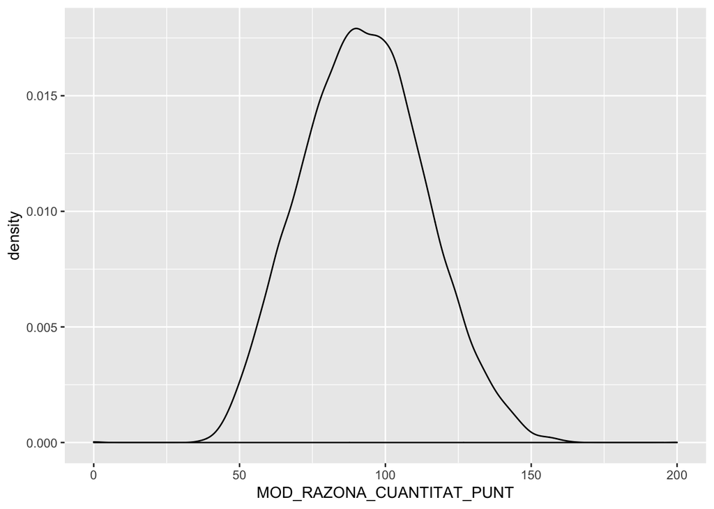

```r
ggplot(subset_sabertyt) +
  geom_density(aes(x = MOD_RAZONA_CUANTITAT_PUNT))
```

2. La cantidad de valores que se encuentran por encima del valor máximo y por debajo del valor mínimo es:

Respuesta:

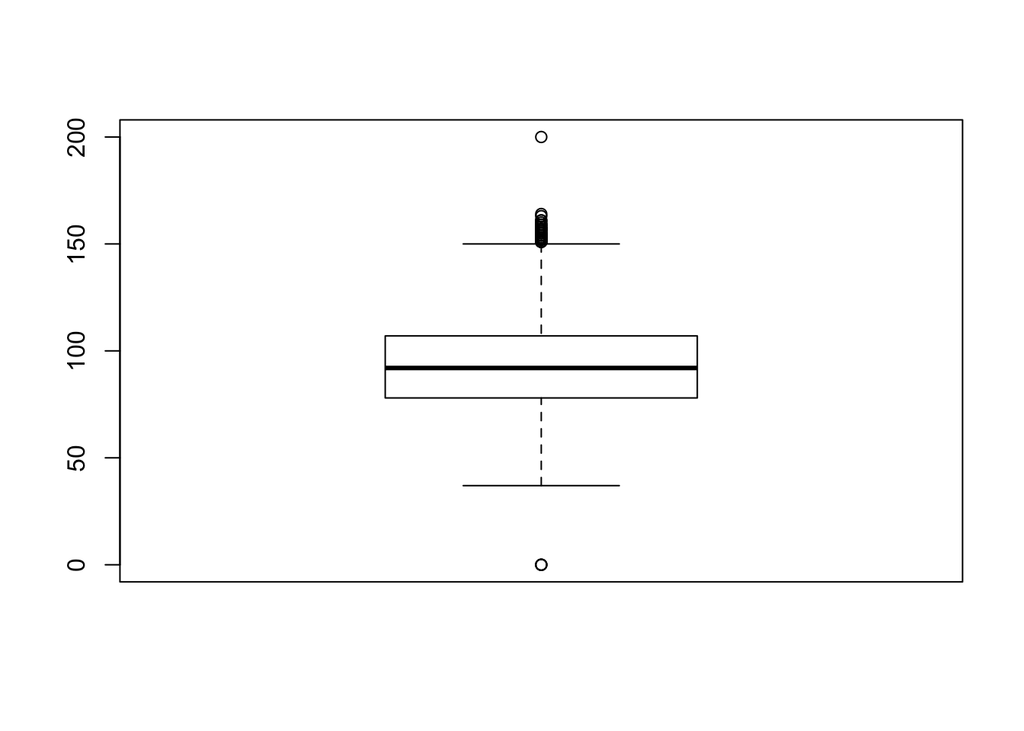

```r
outliers <- boxplot(subset_sabertyt$MOD_RAZONA_CUANTITAT_PUNT)$out
```

```r
length(which(subset_sabertyt$MOD_RAZONA_CUANTITAT_PUNT %in% outliers))
```

```
## [1] 47
```

## 2.5 6

¿Cuáles son las primeras 3 instituciones de nivel técnico profesional en Bogotá que obtuvieron el mejor puntaje promedio en razonamiento cuantitativo (el promedio de los puntajes de sus evaluados) en la sprueba Saber TyT en 2016-2? Indique los nombres de las instituciones, ordenadas de mayor a menor puntaje, copiando los nombres tal cual desde la consola de R.

```r
sub <- data %>%
  filter(INST_CARACTER_ACADEMICO == "T\xc9CNICA PROFESIONAL" & ESTU_INST_MUNICIPIO == "BOGOT\xc1 D.C.") %>%
  group_by(INST_NOMBRE_INSTITUCION) %>%
  summarize(
    PROMEDIO_RAZONAMIENTO = mean(MOD_RAZONA_CUANTITAT_PUNT)
  ) %>%
  arrange(-PROMEDIO_RAZONAMIENTO) %>%
  top_n(3)
sub$INST_NOMBRE_INSTITUCION
```

```
## [1] FUNDACION INTERAMERICANA TECNICA-FIT-BOGOT\xc1 D.C.
## [2] CORPORACION UNIVERSITARIA TALLER CINCO CENTRO DE DISE\xd1O-BOGOT\xc1 D.C.
## [3] CORPORACION POLITECNICO COLOMBO ANDINO-BOGOT\xc1 D.C.
## 203 Levels: CENTRO DE EDUCACION MILITAR-BOGOT\xc1 D.C. ...
```